# Modeling and Scoring with Revolution R Enterprise

April 1, 2016

## Introduction

## URL for Today

Please refer to the following url for today's materials: http://tinyurl.com/j7okpak

## Session Plan

### What to Expect

- We will learn in this tutorial how to train and test models with Revolution R Enterprise.
- Use your knowledge of data manipulation to create **train** and **test** sets.
- Use the modeling functions in RRE to estimate a model.
- Use the `rxPredict` function to test/score a model.
- We will see how you can score models on a variety of data sources.
- Use a functional methodology, i.e., we will create functions to automate the modeling, validation, and scoring process.

## Prerequisites

- Understanding of `rxDataStep` and `xdfs`
- Familiarity with `RevoScaleR` modeling and datastep functions: `rxLinMod`, `rxGlm`, `rxLogit`, `rxDTree`, `rxDForest`, `rxSplit`, and `rxPredict`
- Understand how to write functions in R
- Access to at least one interesting dataset

## Typical Lifecycle

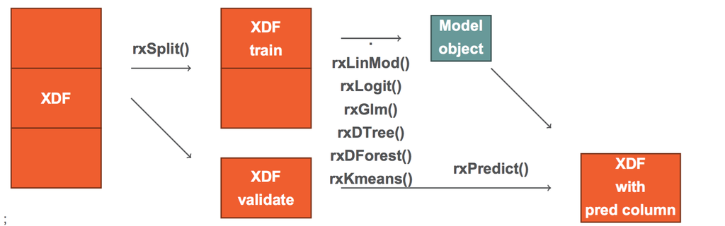

Typical Modeling Lifecycle:

- Start with a data set
- Split into a training set and validation set(s)
- Use the `ScaleR` modeling functions on the train set to estimate your model
- Use `rxPredict` to validate/score your results

## Datasets

### Mortgage Dataset

- We will work with mortgage dataset, which contains mortgage and credit profiles for various mortgage holders

```r
mort_path <- paste(rxGetOption("sampleDataDir"),
                   "mortDefaultSmall.xdf",
                   sep = "/")
file.copy(mort_path, "mortgage.xdf", overwrite = TRUE)
```

```
## [1] TRUE
```

```r
mort_xdf <- RxXdfData("mortgage.xdf")
rxGetInfo(mort_xdf, getVarInfo = TRUE)
```

```
## File name: /home/alizaidi/rre-modeling-scoring/mortgage.xdf
## Number of observations: 1e+05
## Number of variables: 6
## Number of blocks: 10
## Compression type: zlib
## Variable information:
## Var 1: creditScore, Type: integer, Low/High: (470, 925)
## Var 2: houseAge, Type: integer, Low/High: (0, 40)
## Var 3: yearsEmploy, Type: integer, Low/High: (0, 14)
## Var 4: ccDebt, Type: integer, Low/High: (0, 14094)
## Var 5: year, Type: integer, Low/High: (2000, 2009)
## Var 6: default, Type: integer, Low/High: (0, 1)
```

## Datasets

### Convert Default to Categorical

- We might be interested in estimating a classification model for predicting defaults based on credit attributes

```r
rxDataStep(inData = mort_xdf,
           outFile = mort_xdf,
           overwrite = TRUE,
           transforms = list(default_flag = factor(ifelse(default == 1,
                                                          "default",
                                                          "current"))
                             )
           )
```

```
## Rows Read: 10000, Total Rows Processed: 10000, Total Chunk Time: 0.017 secondsRows Read: 10000, Total Rows Processed: 20000, Total Chunk Time: 0.017 secondsRows Read: 10000, Total Rows Processed: 30000, Total Chunk Time: 0.016 secondsRows Read: 10000, Total Rows Processed: 40000, Total Chunk Time…
```

## Modeling

## Generating Training and Test Sets

### Create Partition

- The first step to estimating a model is having a clean training dataset.
- We will work with the mortgage data and use `rxSplit` to create partitions.
- `rxSplit` splits an input `.xdf` into multiple `.xdfs`, similar in spirit to the `split` function in base R
- output is a list
- First step is to create a split variable
- We will randomly partition the data into a train and test sample, with 75% in the former, and 25% in the latter

## Generating Training and Test Sets

### Partition Function

```r
create_partition <- function(xdf = mort_xdf,
                             partition_size = 0.75,
                             output_path = "/output/", ...) {
  rxDataStep(inData = xdf,
             outFile = xdf,
             transforms = list(
               trainvalidate = factor(
                   ifelse(rbinom(.rxNumRows,
                                 size = 1, prob = splitperc),
                          "train", "validate")
               )
           ),
           transformObjects = list(splitperc = partition_size),
           overwrite = TRUE, ...)

  splitDS <- rxSplit(inData = xdf,
                     outFilesBase = "",
                     outFileSuffixes = c("train", "validate"),
                     splitByFactor = "trainvalidate",
                     overwrite = TRUE)

  return(splitDS)

}
```

## Generating Training and Test Sets

### List of xdfs

- The `create_partition` function will output a list `xdfs`

```r
mort_split <- create_partition()
```

```
## Rows Read: 10000, Total Rows Processed: 10000, Total Chunk Time: 0.018 secondsRows Read: 10000, Total Rows Processed: 20000, Total Chunk Time: 0.018 secondsRows Read: 10000, Total Rows Processed: 30000, Total Chunk Time: 0.019 secondsRows Read: 10000, Total Rows Processed: 40000, Total Chunk Time…
## Rows Read: 10000, Total Rows Processed: 10000, Total Chunk Time: 0.054 secondsRows Read: 10000, Total Rows Processed: 20000, Total Chunk Time: 0.050 secondsRows Read: 10000, Total Rows Processed: 30000, Total Chunk Time: 0.050 secondsRows Read: 10000, Total Rows Processed: 40000, Total Chunk Time…
```

```r
names(mort_split) <- c("train", "validate")
lapply(mort_split, rxGetInfo)
```

```
## $train
## File name: /home/alizaidi/rre-modeling-scoring/mortgage.trainvalidate.train.xdf
## Number of observations: 74962
## Number of variables: 8
## Number of blocks: 10
## Compression type: zlib
##
## $validate
## File name: /home/alizaidi/rre-modeling-scoring/mortgage.trainvalidate.validate.xdf
## Number of observations: 25038
## Number of variables: 8
## Number of blocks: 10
## Compression type: zlib
```

## Build Your Model

### Model Formula

- Once you have your training dataset, the most appropriate next step is to estimate your model
- `ScaleR` provides a plethora of modeling functions to choose from: decision trees, ensemble trees, linear models, and generalized linear models.

```r
make_form <- function(xdf = mort_xdf,
                      resp_var = "default_flag",
                      vars_to_skip = c("default", "trainvalidate")) {

  library(stringr)

  non_incl <- paste(vars_to_skip, collapse = "|")

  x_names <- names(xdf)

  features <- x_names[!str_detect(x_names, resp_var)]
  features <- features[!str_detect(features, non_incl)]

  form <- as.formula(paste(resp_var, paste0(features, collapse = " + "),
                           sep  = " ~ "))

  return(form)
}
```

## Build Your Model

### Modeling Function

- Use the `make_form` function inside your favorite `rx` modeling function

```r
make_form()
```

```
## default_flag ~ creditScore + houseAge + yearsEmploy + ccDebt +
##     year
## <environment: 0x612b5c8>
```

```r
estimate_model <- function(xdf_data = mort_split[["train"]],
                           form = make_form(xdf_data),
                           model = rxLogit, ...) {

  rx_model <- model(form, data = xdf_data)

  return(rx_model)


}
```

## Build Your Model

### Estimate Your Model

- Let us now train our model using the `estimate_model` function from the last slide

```r
default_model_logit <- estimate_model(mort_split$train,
                                      reportProgress = 0)
```

```
## Rows Read: 7491, Total Rows Processed: 7491, Total Chunk Time: 0.002 seconds
## Rows Read: 7528, Total Rows Processed: 15019, Total Chunk Time: 0.004 seconds
## Rows Read: 7487, Total Rows Processed: 22506, Total Chunk Time: 0.003 seconds
## Rows Read: 7454, Total Rows Processed: 29960, Total Chunk Time: 0.003 seconds
## Rows Read: 7501, Total Rows Processed: 37461, Total Chunk Time: 0.003 seconds
## Rows Read: 7581, Total Rows Processed: 45042, Total Chunk Time: 0.003 seconds
## Rows Read: 7537, Total Rows Processed: 52579, Total Chunk Time: 0.003 seconds
## Rows Read: 7455, Total Rows Processed: 60034, Total Chunk Time: 0.003 seconds
## Rows Read: 7467, Total Rows Processed: 67501, Total Chunk Time: 0.003 seconds
## Rows Read: 7461, Total Rows Processed: 74962, Total Chunk Time: 0.003 seconds
##
## Starting values (iteration 1) time: 0.038 secs.
## Rows Read: 7491, Total Rows Processed: 7491, Total Chunk Time: 0.002 seconds
## Rows Read: 7528, Total Rows Processed: 15019, Total Chunk Time: 0.005 seconds
## Rows Read: 7487, Total Rows Processed: 22506, Total Chunk Time: 0.004 seconds
## Rows Read: 7454, Total Rows Processed: 29960, Total Chunk Time: 0.004 seconds
## Rows Read: 7501, Total Rows Processed: 37461, Total Chunk Time: 0.005 seconds
## Rows Read: 7581, Total Rows Processed: 45042, Total Chunk Time: 0.004 seconds
## Rows Read: 7537, Total Rows Processed: 52579, Total Chunk Time: 0.004 seconds
## Rows Read: 7455, Total Rows Processed: 60034, Total Chunk Time: 0.004 seconds
## Rows Read: 7467, Total Rows Processed: 67501, Total Chunk Time: 0.004 seconds
## Rows Read: 7461, Total Rows Processed: 74962, Total Chunk Time: 0.004 seconds
##
## Iteration 2 time: 0.054 secs.
## Rows Read: 7491, Total Rows Processed: 7491, Total Chunk Time: 0.001 seconds
## Rows Read: 7528, Total Rows Processed: 15019, Total Chunk Time: 0.004 seconds
## Rows Read: 7487, Total Rows Processed: 22506, Total Chunk Time: 0.004 seconds
## Rows Read: 7454, Total Rows Processed: 29960, Total Chunk Time: 0.004 seconds
## Rows Read: 7501, Total Rows Processed: 37461, Total Chunk Time: 0.004 seconds
## Rows Read: 7581, Total Rows Processed: 45042, Total Chunk Time: 0.004 seconds
## Rows Read: 7537, Total Rows Processed: 52579, Total Chunk Time: 0.004 seconds
## Rows Read: 7455, Total Rows Processed: 60034, Total Chunk Time: 0.004 seconds
## Rows Read: 7467, Total Rows Processed: 67501, Total Chunk Time: 0.004 seconds
## Rows Read: 7461, Total Rows Processed: 74962, Total Chunk Time: 0.004 seconds
##
## Iteration 3 time: 0.049 secs.
## Rows Read: 7491, Total Rows Processed: 7491, Total Chunk Time: 0.001 seconds
## Rows Read: 7528, Total Rows Processed: 15019, Total Chunk Time: 0.004 seconds
## Rows Read: 7487, Total Rows Processed: 22506, Total Chunk Time: 0.004 seconds
## Rows Read: 7454, Total Rows Processed: 29960, Total Chunk Time: 0.004 seconds
```

[output cut: 55 more lines]

```
## Iteration 8 time: 0.050 secs.
## Rows Read: 7491, Total Rows Processed: 7491, Total Chunk Time: 0.002 seconds
## Rows Read: 7528, Total Rows Processed: 15019, Total Chunk Time: 0.004 seconds
## Rows Read: 7487, Total Rows Processed: 22506, Total Chunk Time: 0.004 seconds
## Rows Read: 7454, Total Rows Processed: 29960, Total Chunk Time: 0.004 seconds
## Rows Read: 7501, Total Rows Processed: 37461, Total Chunk Time: 0.004 seconds
## Rows Read: 7581, Total Rows Processed: 45042, Total Chunk Time: 0.004 seconds
## Rows Read: 7537, Total Rows Processed: 52579, Total Chunk Time: 0.004 seconds
## Rows Read: 7455, Total Rows Processed: 60034, Total Chunk Time: 0.004 seconds
## Rows Read: 7467, Total Rows Processed: 67501, Total Chunk Time: 0.004 seconds
## Rows Read: 7461, Total Rows Processed: 74962, Total Chunk Time: 0.004 seconds
##
## Iteration 9 time: 0.049 secs.
##
## Elapsed computation time: 0.443 secs.
```

## Building Additional Models

### Reusing our Function

- We can change the parameters of the `estimate_model` function to create a different model relatively quickly

```r
default_model_tree <- estimate_model(mort_split$train,
                                     model = rxDTree,
                                     cp = 0, type = 'class')
```

```
## Rows Read: 7491, Total Rows Processed: 7491, Total Chunk Time: 0.002 seconds
## Rows Read: 7528, Total Rows Processed: 15019, Total Chunk Time: 0.006 seconds
## Rows Read: 7487, Total Rows Processed: 22506, Total Chunk Time: 0.009 seconds
## Rows Read: 7454, Total Rows Processed: 29960, Total Chunk Time: 0.007 seconds
## Rows Read: 7501, Total Rows Processed: 37461, Total Chunk Time: 0.008 seconds
## Rows Read: 7581, Total Rows Processed: 45042, Total Chunk Time: 0.018 seconds
## Rows Read: 7537, Total Rows Processed: 52579, Total Chunk Time: 0.009 seconds
## Rows Read: 7455, Total Rows Processed: 60034, Total Chunk Time: 0.007 seconds
## Rows Read: 7467, Total Rows Processed: 67501, Total Chunk Time: 0.007 seconds
## Rows Read: 7461, Total Rows Processed: 74962, Total Chunk Time: 0.007 seconds
## Rows Read: 7491, Total Rows Processed: 7491, Total Chunk Time: 0.002 seconds
## Rows Read: 7528, Total Rows Processed: 15019, Total Chunk Time: 0.009 seconds
## Rows Read: 7487, Total Rows Processed: 22506, Total Chunk Time: 0.012 seconds
## Rows Read: 7454, Total Rows Processed: 29960, Total Chunk Time: 0.012 seconds
## Rows Read: 7501, Total Rows Processed: 37461, Total Chunk Time: 0.012 seconds
## Rows Read: 7581, Total Rows Processed: 45042, Total Chunk Time: 0.012 seconds
## Rows Read: 7537, Total Rows Processed: 52579, Total Chunk Time: 0.012 seconds
## Rows Read: 7455, Total Rows Processed: 60034, Total Chunk Time: 0.012 seconds
## Rows Read: 7467, Total Rows Processed: 67501, Total Chunk Time: 0.012 seconds
## Rows Read: 7461, Total Rows Processed: 74962, Total Chunk Time: 0.012 seconds
## Rows Read: 7491, Total Rows Processed: 7491, Total Chunk Time: 0.002 seconds
## Rows Read: 7528, Total Rows Processed: 15019, Total Chunk Time: 0.011 seconds
## Rows Read: 7487, Total Rows Processed: 22506, Total Chunk Time: 0.014 seconds
## Rows Read: 7454, Total Rows Processed: 29960, Total Chunk Time: 0.013 seconds
## Rows Read: 7501, Total Rows Processed: 37461, Total Chunk Time: 0.013 seconds
## Rows Read: 7581, Total Rows Processed: 45042, Total Chunk Time: 0.014 seconds
## Rows Read: 7537, Total Rows Processed: 52579, Total Chunk Time: 0.013 seconds
## Rows Read: 7455, Total Rows Processed: 60034, Total Chunk Time: 0.014 seconds
## Rows Read: 7467, Total Rows Processed: 67501, Total Chunk Time: 0.013 seconds
## Rows Read: 7461, Total Rows Processed: 74962, Total Chunk Time: 0.014 seconds
## Rows Read: 2, Total Rows Processed: 2, Total Chunk Time: 0.002 seconds
## Rows Read: 7491, Total Rows Processed: 7491, Total Chunk Time: 0.002 seconds
## Rows Read: 7528, Total Rows Processed: 15019, Total Chunk Time: 0.011 seconds
## Rows Read: 7487, Total Rows Processed: 22506, Total Chunk Time: 0.014 seconds
## Rows Read: 7454, Total Rows Processed: 29960, Total Chunk Time: 0.014 seconds
## Rows Read: 7501, Total Rows Processed: 37461, Total Chunk Time: 0.013 seconds
## Rows Read: 7581, Total Rows Processed: 45042, Total Chunk Time: 0.012 seconds
## Rows Read: 7537, Total Rows Processed: 52579, Total Chunk Time: 0.013 seconds
## Rows Read: 7455, Total Rows Processed: 60034, Total Chunk Time: 0.012 seconds
## Rows Read: 7467, Total Rows Processed: 67501, Total Chunk Time: 0.013 seconds
```

[output cut: 317 more lines]

```
## Rows Read: 7491, Total Rows Processed: 7491, Total Chunk Time: 0.001 seconds
## Rows Read: 7528, Total Rows Processed: 15019, Total Chunk Time: 0.002 seconds
## Rows Read: 7487, Total Rows Processed: 22506, Total Chunk Time: 0.002 seconds
## Rows Read: 7454, Total Rows Processed: 29960, Total Chunk Time: 0.002 seconds
## Rows Read: 7501, Total Rows Processed: 37461, Total Chunk Time: 0.002 seconds
## Rows Read: 7581, Total Rows Processed: 45042, Total Chunk Time: 0.002 seconds
## Rows Read: 7537, Total Rows Processed: 52579, Total Chunk Time: 0.002 seconds
## Rows Read: 7455, Total Rows Processed: 60034, Total Chunk Time: 0.002 seconds
## Rows Read: 7467, Total Rows Processed: 67501, Total Chunk Time: 0.002 seconds
## Rows Read: 7461, Total Rows Processed: 74962, Total Chunk Time: 0.002 seconds
##
## Elapsed time for DTreeEstimation: 4.375 secs.
##
## Elapsed time for BxDTreeBase: 4.379 secs.
##
```

## Validation

## How Does it Perform on Unseen Data

### rxPredict for Logistic Regression

```
## [1] TRUE
```

- Now that we have built our model, our next step is to see how it performs on data it has yet to see
- We can use the `rxPredict` function to score/validate our results

```r
default_logit_scored <- rxPredict(default_model_logit,
                                   mort_split$validate,
                                   "scored.xdf",
                                  writeModelVars = TRUE)
```

```
## Rows Read: 2509, Total Rows Processed: 2509, Total Chunk Time: 0.001 seconds
## Rows Read: 2472, Total Rows Processed: 4981, Total Chunk Time: 0.005 seconds
## Rows Read: 2513, Total Rows Processed: 7494, Total Chunk Time: 0.004 seconds
## Rows Read: 2546, Total Rows Processed: 10040, Total Chunk Time: 0.004 seconds
## Rows Read: 2499, Total Rows Processed: 12539, Total Chunk Time: 0.004 seconds
## Rows Read: 2419, Total Rows Processed: 14958, Total Chunk Time: 0.004 seconds
## Rows Read: 2463, Total Rows Processed: 17421, Total Chunk Time: 0.004 seconds
## Rows Read: 2545, Total Rows Processed: 19966, Total Chunk Time: 0.004 seconds
## Rows Read: 2533, Total Rows Processed: 22499, Total Chunk Time: 0.004 seconds
## Rows Read: 2539, Total Rows Processed: 25038, Total Chunk Time: 0.004 seconds
```

## Get Receiver Operator Characteristics

- We can visualize our test results

```r
rxGetInfo(default_logit_scored, numRows = 2)
```

```
## File name: /home/alizaidi/rre-modeling-scoring/scored.xdf
## Number of observations: 25038
## Number of variables: 7
## Number of blocks: 10
## Compression type: zlib
## Data (2 rows starting with row 1):
##   default_flag_Pred default_flag creditScore houseAge yearsEmploy ccDebt
## 1      5.518520e-06      current         691        4           4   5077
## 2      1.028133e-06      current         724        6           5   4057
##   year
## 1 2000
## 2 2000
```

```r
rxDataStep(inData = default_logit_scored,
           outFile = default_logit_scored,
           transforms = list(default_binary = ifelse(default_flag == "default",
                                                     1,
                                                     0)),
           overwrite = TRUE)
```

```
## Rows Read: 2509, Total Rows Processed: 2509, Total Chunk Time: 0.007 secondsRows Read: 2472, Total Rows Processed: 4981, Total Chunk Time: 0.007 secondsRows Read: 2513, Total Rows Processed: 7494, Total Chunk Time: 0.007 secondsRows Read: 2546, Total Rows Processed: 10040, Total Chunk Time: 0.007…
```

## Visualize Model Results

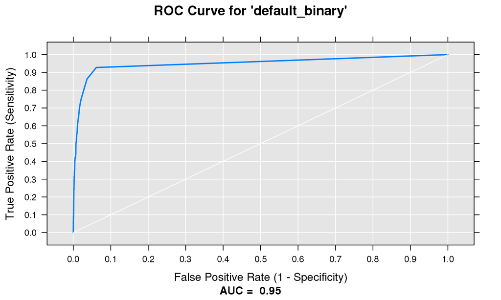

```r
rxRocCurve("default_binary", "default_flag_Pred", data = default_logit_scored)
```

## Testing a Second Model

### rxPredict for Decision Tree

- We saw how easy it was to train on different in the previous sections
- Similary simple to test different models

```r
default_tree_scored <- rxPredict(default_model_tree,
                                  mort_split$validate,
                                  "scored.xdf",
                                  writeModelVars = TRUE)
```

```
## Rows Read: 2509, Total Rows Processed: 2509, Total Chunk Time: 0.001 seconds
## Rows Read: 2472, Total Rows Processed: 4981, Total Chunk Time: 0.009 seconds
## Rows Read: 2513, Total Rows Processed: 7494, Total Chunk Time: 0.007 seconds
## Rows Read: 2546, Total Rows Processed: 10040, Total Chunk Time: 0.007 seconds
## Rows Read: 2499, Total Rows Processed: 12539, Total Chunk Time: 0.008 seconds
## Rows Read: 2419, Total Rows Processed: 14958, Total Chunk Time: 0.008 seconds
## Rows Read: 2463, Total Rows Processed: 17421, Total Chunk Time: 0.007 seconds
## Rows Read: 2545, Total Rows Processed: 19966, Total Chunk Time: 0.007 seconds
## Rows Read: 2533, Total Rows Processed: 22499, Total Chunk Time: 0.008 seconds
## Rows Read: 2539, Total Rows Processed: 25038, Total Chunk Time: 0.008 seconds
```

## Visualize Multiple ROCs

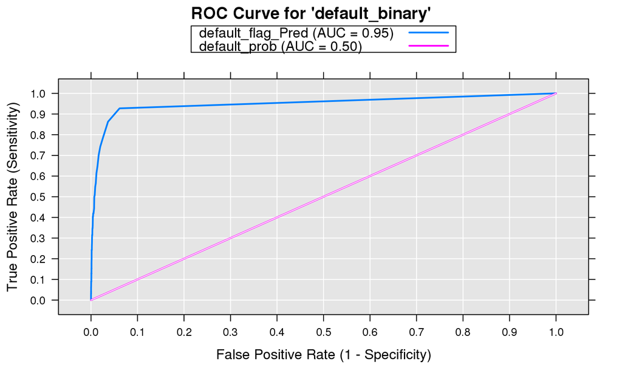

```r
rxRocCurve("default_binary",
           c("default_flag_Pred", "default_prob"),
           data = default_tree_scored)
```

## More Advanced Topics

## Scoring on Non-XDF Data Sources

### Using CSV

- The previous slides focused on using xdf data sources
- Most of the `rx` functions will work on non-xdf data sources
- For training, which is often an iterative process, it is recommended to use xdfs
- For scoring/testing, which requires just one pass through the data, feel free to use raw data!

```r
csv_path <- paste(rxGetOption("sampleDataDir"),
                   "mortDefaultSmall2009.csv",
                   sep = "/")
file.copy(csv_path, "mortDefaultSmall2009.csv", overwrite = TRUE)
```

```
## [1] TRUE
```

```r
mort_csv <- RxTextData("mortDefaultSmall2009.csv")
```

## Regression Tree

- For a slightly different model, we will estimate a regression tree.
- Just change the parameters in the `estimate_model` function

```r
tree_model_ccdebt <- estimate_model(xdf_data = mort_split$train,
                                    form = make_form(mort_split$train,
                                                     "ccDebt",
                                                     vars_to_skip = c("default_flag",
                                                                      "trainvalidate")),
                                    model = rxDTree)
```

```
## Rows Read: 7491, Total Rows Processed: 7491, Total Chunk Time: 0.002 seconds
## Rows Read: 7528, Total Rows Processed: 15019, Total Chunk Time: 0.005 seconds
## Rows Read: 7487, Total Rows Processed: 22506, Total Chunk Time: 0.009 seconds
## Rows Read: 7454, Total Rows Processed: 29960, Total Chunk Time: 0.009 seconds
## Rows Read: 7501, Total Rows Processed: 37461, Total Chunk Time: 0.009 seconds
## Rows Read: 7581, Total Rows Processed: 45042, Total Chunk Time: 0.008 seconds
## Rows Read: 7537, Total Rows Processed: 52579, Total Chunk Time: 0.008 seconds
## Rows Read: 7455, Total Rows Processed: 60034, Total Chunk Time: 0.008 seconds
## Rows Read: 7467, Total Rows Processed: 67501, Total Chunk Time: 0.009 seconds
## Rows Read: 7461, Total Rows Processed: 74962, Total Chunk Time: 0.008 seconds
## Rows Read: 7491, Total Rows Processed: 7491, Total Chunk Time: 0.002 seconds
## Rows Read: 7528, Total Rows Processed: 15019, Total Chunk Time: 0.007 seconds
## Rows Read: 7487, Total Rows Processed: 22506, Total Chunk Time: 0.014 seconds
## Rows Read: 7454, Total Rows Processed: 29960, Total Chunk Time: 0.013 seconds
## Rows Read: 7501, Total Rows Processed: 37461, Total Chunk Time: 0.012 seconds
## Rows Read: 7581, Total Rows Processed: 45042, Total Chunk Time: 0.012 seconds
## Rows Read: 7537, Total Rows Processed: 52579, Total Chunk Time: 0.012 seconds
## Rows Read: 7455, Total Rows Processed: 60034, Total Chunk Time: 0.012 seconds
## Rows Read: 7467, Total Rows Processed: 67501, Total Chunk Time: 0.012 seconds
## Rows Read: 7461, Total Rows Processed: 74962, Total Chunk Time: 0.012 seconds
## Rows Read: 7491, Total Rows Processed: 7491, Total Chunk Time: 0.002 seconds
## Rows Read: 7528, Total Rows Processed: 15019, Total Chunk Time: 0.007 seconds
## Rows Read: 7487, Total Rows Processed: 22506, Total Chunk Time: 0.012 seconds
## Rows Read: 7454, Total Rows Processed: 29960, Total Chunk Time: 0.012 seconds
## Rows Read: 7501, Total Rows Processed: 37461, Total Chunk Time: 0.012 seconds
## Rows Read: 7581, Total Rows Processed: 45042, Total Chunk Time: 0.012 seconds
## Rows Read: 7537, Total Rows Processed: 52579, Total Chunk Time: 0.012 seconds
## Rows Read: 7455, Total Rows Processed: 60034, Total Chunk Time: 0.012 seconds
## Rows Read: 7467, Total Rows Processed: 67501, Total Chunk Time: 0.012 seconds
## Rows Read: 7461, Total Rows Processed: 74962, Total Chunk Time: 0.012 seconds
## Rows Read: 2, Total Rows Processed: 2, Total Chunk Time: 0.005 seconds
## Rows Read: 7491, Total Rows Processed: 7491, Total Chunk Time: 0.002 seconds
## Rows Read: 7528, Total Rows Processed: 15019, Total Chunk Time: 0.007 seconds
## Rows Read: 7487, Total Rows Processed: 22506, Total Chunk Time: 0.012 seconds
## Rows Read: 7454, Total Rows Processed: 29960, Total Chunk Time: 0.012 seconds
## Rows Read: 7501, Total Rows Processed: 37461, Total Chunk Time: 0.012 seconds
## Rows Read: 7581, Total Rows Processed: 45042, Total Chunk Time: 0.012 seconds
## Rows Read: 7537, Total Rows Processed: 52579, Total Chunk Time: 0.013 seconds
## Rows Read: 7455, Total Rows Processed: 60034, Total Chunk Time: 0.013 seconds
## Rows Read: 7467, Total Rows Processed: 67501, Total Chunk Time: 0.012 seconds
```

[output cut: 350 more lines]

```
## Rows Read: 7491, Total Rows Processed: 7491, Total Chunk Time: 0.001 seconds
## Rows Read: 7528, Total Rows Processed: 15019, Total Chunk Time: 0.005 seconds
## Rows Read: 7487, Total Rows Processed: 22506, Total Chunk Time: 0.005 seconds
## Rows Read: 7454, Total Rows Processed: 29960, Total Chunk Time: 0.005 seconds
## Rows Read: 7501, Total Rows Processed: 37461, Total Chunk Time: 0.005 seconds
## Rows Read: 7581, Total Rows Processed: 45042, Total Chunk Time: 0.005 seconds
## Rows Read: 7537, Total Rows Processed: 52579, Total Chunk Time: 0.005 seconds
## Rows Read: 7455, Total Rows Processed: 60034, Total Chunk Time: 0.005 seconds
## Rows Read: 7467, Total Rows Processed: 67501, Total Chunk Time: 0.005 seconds
## Rows Read: 7461, Total Rows Processed: 74962, Total Chunk Time: 0.006 seconds
##
## Elapsed time for DTreeEstimation: 5.312 secs.
##
## Elapsed time for BxDTreeBase: 5.317 secs.
##
```

```r
# plot(RevoTreeView::createTreeView(tree_model_ccdebt))
```

## Test on CSV

```
## [1] TRUE
```

```r
rxPredict(tree_model_ccdebt,
          data = mort_csv,
          outData = "mort2009predictions.xdf",
          writeModelVars = TRUE)
```

```
## Rows Read: 10000, Total Rows Processed: 10000, Total Chunk Time: 0.058 seconds
```

```r
mort_2009_pred <- RxXdfData("mort2009predictions.xdf")
rxGetInfo(mort_2009_pred, numRows = 1)
```

```
## File name: /home/alizaidi/rre-modeling-scoring/mort2009predictions.xdf
## Number of observations: 10000
## Number of variables: 7
## Number of blocks: 1
## Compression type: zlib
## Data (1 row starting with row 1):
##   ccDebt_Pred ccDebt creditScore houseAge yearsEmploy year default
## 1    4859.859   3661         701       23           2 2009       0
```

## Multiclass Classification

## Convert Year to Factor

- We have seen how to estimate a binary classification model and a regression tree
- How would we estimate a multiclass classification model?
- Let's try to predict mortgage origination based on other variables
- Use `rxFactors` to convert *year* to a *factor* variable

```r
mort_xdf_factor <- rxFactors(inData = mort_xdf,
                             factorInfo = c("year"),
                             outFile = "mort_year.xdf",
                             overwrite = TRUE)
```

```
## Rows Read: 10000, Total Rows Processed: 10000, Total Chunk Time: 0.013 seconds
## Rows Read: 10000, Total Rows Processed: 20000, Total Chunk Time: 0.016 seconds
## Rows Read: 10000, Total Rows Processed: 30000, Total Chunk Time: 0.016 seconds
## Rows Read: 10000, Total Rows Processed: 40000, Total Chunk Time: 0.016 seconds
## Rows Read: 10000, Total Rows Processed: 50000, Total Chunk Time: 0.016 seconds
## Rows Read: 10000, Total Rows Processed: 60000, Total Chunk Time: 0.017 seconds
## Rows Read: 10000, Total Rows Processed: 70000, Total Chunk Time: 0.017 seconds
## Rows Read: 10000, Total Rows Processed: 80000, Total Chunk Time: 0.017 seconds
## Rows Read: 10000, Total Rows Processed: 90000, Total Chunk Time: 0.017 seconds
## Rows Read: 10000, Total Rows Processed: 100000, Total Chunk Time: 0.017 seconds
```

## Convert Year to Factor

```r
rxGetInfo(mort_xdf_factor, getVarInfo = TRUE)
```

```
## File name: /home/alizaidi/rre-modeling-scoring/mort_year.xdf
## Number of observations: 1e+05
## Number of variables: 8
## Number of blocks: 10
## Compression type: zlib
## Variable information:
## Var 1: creditScore, Type: integer, Low/High: (470, 925)
## Var 2: houseAge, Type: integer, Low/High: (0, 40)
## Var 3: yearsEmploy, Type: integer, Low/High: (0, 14)
## Var 4: ccDebt, Type: integer, Low/High: (0, 14094)
## Var 5: year
##        10 factor levels: 2000 2001 2002 2003 2004 2005 2006 2007 2008 2009
## Var 6: default, Type: integer, Low/High: (0, 1)
## Var 7: default_flag
##        2 factor levels: current default
## Var 8: trainvalidate
##        2 factor levels: train validate
```

## Estimate Multiclass Classification

- You know the drill! Change the parameters in `estimate_model`:

```r
tree_multiclass_year <- estimate_model(xdf_data = mort_xdf_factor,
                                    form = make_form(mort_xdf_factor,
                                                     "year",
                                                     vars_to_skip = c("default",
                                                                      "trainvalidate")),
                                    model = rxDTree, type = "class")
```

```
## Rows Read: 10000, Total Rows Processed: 10000, Total Chunk Time: 0.002 seconds
## Rows Read: 10000, Total Rows Processed: 20000, Total Chunk Time: 0.006 seconds
## Rows Read: 10000, Total Rows Processed: 30000, Total Chunk Time: 0.010 seconds
## Rows Read: 10000, Total Rows Processed: 40000, Total Chunk Time: 0.006 seconds
## Rows Read: 10000, Total Rows Processed: 50000, Total Chunk Time: 0.005 seconds
## Rows Read: 10000, Total Rows Processed: 60000, Total Chunk Time: 0.005 seconds
## Rows Read: 10000, Total Rows Processed: 70000, Total Chunk Time: 0.006 seconds
## Rows Read: 10000, Total Rows Processed: 80000, Total Chunk Time: 0.005 seconds
## Rows Read: 10000, Total Rows Processed: 90000, Total Chunk Time: 0.005 seconds
## Rows Read: 10000, Total Rows Processed: 100000, Total Chunk Time: 0.005 seconds
## Rows Read: 10000, Total Rows Processed: 10000, Total Chunk Time: 0.002 seconds
## Rows Read: 10000, Total Rows Processed: 20000, Total Chunk Time: 0.009 seconds
## Rows Read: 10000, Total Rows Processed: 30000, Total Chunk Time: 0.011 seconds
## Rows Read: 10000, Total Rows Processed: 40000, Total Chunk Time: 0.011 seconds
## Rows Read: 10000, Total Rows Processed: 50000, Total Chunk Time: 0.010 seconds
## Rows Read: 10000, Total Rows Processed: 60000, Total Chunk Time: 0.010 seconds
## Rows Read: 10000, Total Rows Processed: 70000, Total Chunk Time: 0.010 seconds
## Rows Read: 10000, Total Rows Processed: 80000, Total Chunk Time: 0.010 seconds
## Rows Read: 10000, Total Rows Processed: 90000, Total Chunk Time: 0.010 seconds
## Rows Read: 10000, Total Rows Processed: 100000, Total Chunk Time: 0.010 seconds
## Rows Read: 10000, Total Rows Processed: 10000, Total Chunk Time: 0.002 seconds
## Rows Read: 10000, Total Rows Processed: 20000, Total Chunk Time: 0.008 seconds
## Rows Read: 10000, Total Rows Processed: 30000, Total Chunk Time: 0.011 seconds
## Rows Read: 10000, Total Rows Processed: 40000, Total Chunk Time: 0.011 seconds
## Rows Read: 10000, Total Rows Processed: 50000, Total Chunk Time: 0.011 seconds
## Rows Read: 10000, Total Rows Processed: 60000, Total Chunk Time: 0.011 seconds
## Rows Read: 10000, Total Rows Processed: 70000, Total Chunk Time: 0.010 seconds
## Rows Read: 10000, Total Rows Processed: 80000, Total Chunk Time: 0.010 seconds
## Rows Read: 10000, Total Rows Processed: 90000, Total Chunk Time: 0.010 seconds
## Rows Read: 10000, Total Rows Processed: 100000, Total Chunk Time: 0.011 seconds
## Rows Read: 2, Total Rows Processed: 2, Total Chunk Time: 0.002 seconds
## Rows Read: 10000, Total Rows Processed: 10000, Total Chunk Time: 0.002 seconds
## Rows Read: 10000, Total Rows Processed: 20000, Total Chunk Time: 0.008 seconds
## Rows Read: 10000, Total Rows Processed: 30000, Total Chunk Time: 0.011 seconds
## Rows Read: 10000, Total Rows Processed: 40000, Total Chunk Time: 0.011 seconds
## Rows Read: 10000, Total Rows Processed: 50000, Total Chunk Time: 0.011 seconds
## Rows Read: 10000, Total Rows Processed: 60000, Total Chunk Time: 0.011 seconds
## Rows Read: 10000, Total Rows Processed: 70000, Total Chunk Time: 0.011 seconds
## Rows Read: 10000, Total Rows Processed: 80000, Total Chunk Time: 0.011 seconds
## Rows Read: 10000, Total Rows Processed: 90000, Total Chunk Time: 0.011 seconds
```

[output cut: 350 more lines]

```
## Rows Read: 10000, Total Rows Processed: 10000, Total Chunk Time: 0.001 seconds
## Rows Read: 10000, Total Rows Processed: 20000, Total Chunk Time: 0.007 seconds
## Rows Read: 10000, Total Rows Processed: 30000, Total Chunk Time: 0.008 seconds
## Rows Read: 10000, Total Rows Processed: 40000, Total Chunk Time: 0.007 seconds
## Rows Read: 10000, Total Rows Processed: 50000, Total Chunk Time: 0.007 seconds
## Rows Read: 10000, Total Rows Processed: 60000, Total Chunk Time: 0.007 seconds
## Rows Read: 10000, Total Rows Processed: 70000, Total Chunk Time: 0.007 seconds
## Rows Read: 10000, Total Rows Processed: 80000, Total Chunk Time: 0.007 seconds
## Rows Read: 10000, Total Rows Processed: 90000, Total Chunk Time: 0.007 seconds
## Rows Read: 10000, Total Rows Processed: 100000, Total Chunk Time: 0.007 seconds
##
## Elapsed time for DTreeEstimation: 5.176 secs.
##
## Elapsed time for BxDTreeBase: 5.181 secs.
##
```

## Predict Multiclass Classification

- Score the results

```r
multiclass_preds <- rxPredict(tree_multiclass_year,
                              data = mort_xdf_factor,
                              writeModelVars = TRUE,
                              outData = "multi.xdf",
                              overwrite = TRUE)
```

```
## Rows Read: 10000, Total Rows Processed: 10000, Total Chunk Time: 0.002 seconds
## Rows Read: 10000, Total Rows Processed: 20000, Total Chunk Time: 0.052 seconds
## Rows Read: 10000, Total Rows Processed: 30000, Total Chunk Time: 0.039 seconds
## Rows Read: 10000, Total Rows Processed: 40000, Total Chunk Time: 0.044 seconds
## Rows Read: 10000, Total Rows Processed: 50000, Total Chunk Time: 0.036 seconds
## Rows Read: 10000, Total Rows Processed: 60000, Total Chunk Time: 0.038 seconds
## Rows Read: 10000, Total Rows Processed: 70000, Total Chunk Time: 0.047 seconds
## Rows Read: 10000, Total Rows Processed: 80000, Total Chunk Time: 0.039 seconds
## Rows Read: 10000, Total Rows Processed: 90000, Total Chunk Time: 0.045 seconds
## Rows Read: 10000, Total Rows Processed: 100000, Total Chunk Time: 0.036 seconds
```

## Predict Multiclass Classification

- View the results
- Predicted/scored column for each level of the response
- Sum up to one

```r
rxGetInfo(multiclass_preds, numRows = 1)
```

```
## File name: /home/alizaidi/rre-modeling-scoring/multi.xdf
## Number of observations: 1e+05
## Number of variables: 14
## Number of blocks: 10
## Compression type: zlib
## Data (1 row starting with row 1):
##    2000_prob  2001_prob  2002_prob  2003_prob 2004_prob 2005_prob
## 1 0.09419223 0.09792822 0.09373939 0.09611683 0.1000792 0.1023435
##   2006_prob 2007_prob 2008_prob 2009_prob year creditScore houseAge ccDebt
## 1 0.1030228 0.1067587 0.1024567 0.1033624 2000         691       16   6725
```

## Conclusion

## Thanks for Attending!

- Any questions?
- Try different models!
- Try modeling with `rxDForest`, `rxBTrees`: have significantly higher predictive accuracy, somewhat less interpretability
- alizaidi@microsoft.com